# Supervised Learning - Foundations Project: ReCell

## Problem Statement

### Business Context

Buying and selling used phones and tablets used to be something that happened on a handful of online marketplace sites. But the used and refurbished device market has grown considerably over the past decade, and a new IDC (International Data Corporation) forecast predicts that the used phone market would be worth \$52.7bn by 2023 with a compound annual growth rate (CAGR) of 13.6% from 2018 to 2023. This growth can be attributed to an uptick in demand for used phones and tablets that offer considerable savings compared with new models.

Refurbished and used devices continue to provide cost-effective alternatives to both consumers and businesses that are looking to save money when purchasing one. There are plenty of other benefits associated with the used device market. Used and refurbished devices can be sold with warranties and can also be insured with proof of purchase. Third-party vendors/platforms, such as Verizon, Amazon, etc., provide attractive offers to customers for refurbished devices. Maximizing the longevity of devices through second-hand trade also reduces their environmental impact and helps in recycling and reducing waste. The impact of the COVID-19 outbreak may further boost this segment as consumers cut back on discretionary spending and buy phones and tablets only for immediate needs.

### Objective

The rising potential of this comparatively under-the-radar market fuels the need for an ML-based solution to develop a dynamic pricing strategy for used and refurbished devices. ReCell, a startup aiming to tap the potential in this market, has hired you as a data scientist. They want you to analyze the data provided and build a linear regression model to predict the price of a used phone/tablet and identify factors that significantly influence it.

### Data Description

The data contains the different attributes of used/refurbished phones and tablets. The data was collected in the year 2021. The detailed data dictionary is given below.

- brand_name: Name of manufacturing brand
- os: OS on which the device runs
- screen_size: Size of the screen in cm
- 4g: Whether 4G is available or not
- 5g: Whether 5G is available or not
- main_camera_mp: Resolution of the rear camera in megapixels
- selfie_camera_mp: Resolution of the front camera in megapixels
- int_memory: Amount of internal memory (ROM) in GB
- ram: Amount of RAM in GB
- battery: Energy capacity of the device battery in mAh
- weight: Weight of the device in grams
- release_year: Year when the device model was released
- days_used: Number of days the used/refurbished device has been used
- normalized_new_price: Normalized price of a new device of the same model in euros
- normalized_used_price: Normalized price of the used/refurbished device in euros

# Problem Definition

Developing a Machine Learning-based solution to develop a dynamic pricing strategy for used and refurbished devices for ReCell, start-up aiming to tap the potential in this market.

Building the model would involve analyzing data and building a linear regression model to predict the price of a used phone/tablet and identify factors that significantly influence it. This would help ReCell to be competitive, among other factors.

# Questions to address

1. What does the distribution of normalized used device prices look like?
2. What percentage of the used device market is dominated by Android devices?
3. The amount of RAM is important for the smooth functioning of a device. How does the amount of RAM vary with the brand?
4. A large battery often increases a device's weight, making it feel uncomfortable in the hands. How does the weight vary for phones and tablets offering large batteries (more than 4500 mAh)?
5. Bigger screens are desirable for entertainment purposes as they offer a better viewing experience. How many phones and tablets are available across different brands with a screen size larger than 6 inches?
6. A lot of devices nowadays offer great selfie cameras, allowing us to capture our favorite moments with loved ones. What is the distribution of devices offering greater than 8MP selfie cameras across brands?
7. Which attributes are highly correlated with the normalized price of a used device?

## Importing necessary libraries

```python
# Installing the libraries with the specified version.
# uncomment and run the following line if Google Colab is being used
# !pip install scikit-learn==1.2.2 seaborn==0.13.1 matplotlib==3.7.1 numpy==1.25.2 pandas==1.5.3 -q --user
```

```python
# Installing the libraries with the specified version.
# uncomment and run the following lines if Jupyter Notebook is being used
# !pip install scikit-learn==1.2.2 seaborn==0.11.1 matplotlib==3.3.4 numpy==1.24.3 pandas==1.5.2 -q --user
```

**Note**: *After running the above cell, kindly restart the notebook kernel and run all cells sequentially from the start again.*

```python
# Libraries to help with reading and manipulating data
import numpy as np
import pandas as pd

# Libraries to help with data visualization
import matplotlib.pyplot as plt
import seaborn as sns

sns.set()

# split the data into train and test
from sklearn.model_selection import train_test_split

# to build linear regression_model
from sklearn.linear_model import LinearRegression

# to check model performance
from sklearn.metrics import mean_absolute_error, mean_squared_error, r2_score

# to build linear regression_model using statsmodels
import statsmodels.api as sm

# to compute VIF
from statsmodels.stats.outliers_influence import variance_inflation_factor
```

## Loading the dataset

```python
# uncomment and run the following lines for Google Colab
# from google.colab import drive
# drive.mount('/content/drive')
```

```python
# Code to let colab access my google drive
from google.colab import drive
drive.mount('/content/drive')
```

```python
# loading data
data = pd.read_csv('/content/drive/My Drive/ReCell_Project/used_device_data.csv') ## Complete the code to read the data
```

## Data Overview

- Observations to check if data has been uploaded properly or not. Here, I check the first five rows and the last 5 rows of the dataset
- Sanity checks to get information about the number of rows and columns in the dataset, find out the data types of the columns to ensure that data is stored in the preferred format and the value of each property is as expected, check the statistical summary of the dataset to get an overview of the numerical columns of the data, check for duplicate values, and missing values.

```python
# Code to view the first 5 rows of the dataset
data.head()
```

|  | brand_name | os | screen_size | 4g | 5g | main_camera_mp | selfie_camera_mp | int_memory | ram | battery | weight | release_year | days_used | normalized_used_price | normalized_new_price |
| --- | --- | --- | --- | --- | --- | --- | --- | --- | --- | --- | --- | --- | --- | --- | --- |
| 0 | Honor | Android | 14.50 | yes | no | 13.0 | 5.0 | 64.0 | 3.0 | 3020.0 | 146.0 | 2020 | 127 | 4.307572 | 4.715100 |
| 1 | Honor | Android | 17.30 | yes | yes | 13.0 | 16.0 | 128.0 | 8.0 | 4300.0 | 213.0 | 2020 | 325 | 5.162097 | 5.519018 |
| 2 | Honor | Android | 16.69 | yes | yes | 13.0 | 8.0 | 128.0 | 8.0 | 4200.0 | 213.0 | 2020 | 162 | 5.111084 | 5.884631 |
| 3 | Honor | Android | 25.50 | yes | yes | 13.0 | 8.0 | 64.0 | 6.0 | 7250.0 | 480.0 | 2020 | 345 | 5.135387 | 5.630961 |
| 4 | Honor | Android | 15.32 | yes | no | 13.0 | 8.0 | 64.0 | 3.0 | 5000.0 | 185.0 | 2020 | 293 | 4.389995 | 4.947837 |

```python
# Code to view the last 5 rows of the dataset
data.tail()
```

|  | brand_name | os | screen_size | 4g | 5g | main_camera_mp | selfie_camera_mp | int_memory | ram | battery | weight | release_year | days_used | normalized_used_price | normalized_new_price |
| --- | --- | --- | --- | --- | --- | --- | --- | --- | --- | --- | --- | --- | --- | --- | --- |
| 3449 | Asus | Android | 15.34 | yes | no | NaN | 8.0 | 64.0 | 6.0 | 5000.0 | 190.0 | 2019 | 232 | 4.492337 | 6.483872 |
| 3450 | Asus | Android | 15.24 | yes | no | 13.0 | 8.0 | 128.0 | 8.0 | 4000.0 | 200.0 | 2018 | 541 | 5.037732 | 6.251538 |
| 3451 | Alcatel | Android | 15.80 | yes | no | 13.0 | 5.0 | 32.0 | 3.0 | 4000.0 | 165.0 | 2020 | 201 | 4.357350 | 4.528829 |
| 3452 | Alcatel | Android | 15.80 | yes | no | 13.0 | 5.0 | 32.0 | 2.0 | 4000.0 | 160.0 | 2020 | 149 | 4.349762 | 4.624188 |
| 3453 | Alcatel | Android | 12.83 | yes | no | 13.0 | 5.0 | 16.0 | 2.0 | 4000.0 | 168.0 | 2020 | 176 | 4.132122 | 4.279994 |

*Observations*

It is clear that the dataset has been uploaded properly, clearly identifying the columns and the rows in the dataset. We can proceed to check the shape of the data to know exactly how many columns and rows are there.

```python
# Code to check the shape of the dataset
data.shape
print('There are', data.shape[0],'rows and', data.shape[1],'columns')
```

```
There are 3454 rows and 15 columns
```

*Observations*

The dataset has 3454 rows and 15 columns.

We can proceed to check the datatypes of the different columns in the dataset.

```python
# Code to determine datatypes of different columns in the dataset
info = data.info()
print(info)
```

```
<class 'pandas.core.frame.DataFrame'>
RangeIndex: 3454 entries, 0 to 3453
Data columns (total 15 columns):
 #   Column                 Non-Null Count  Dtype
---  ------                 --------------  -----
 0   brand_name             3454 non-null   object
 1   os                     3454 non-null   object
 2   screen_size            3454 non-null   float64
 3   4g                     3454 non-null   object
 4   5g                     3454 non-null   object
 5   main_camera_mp         3275 non-null   float64
 6   selfie_camera_mp       3452 non-null   float64
 7   int_memory             3450 non-null   float64
 8   ram                    3450 non-null   float64
 9   battery                3448 non-null   float64
 10  weight                 3447 non-null   float64
 11  release_year           3454 non-null   int64
 12  days_used              3454 non-null   int64
 13  normalized_used_price  3454 non-null   float64
 14  normalized_new_price   3454 non-null   float64
dtypes: float64(9), int64(2), object(4)
memory usage: 404.9+ KB
None
```

*Observations*

Of the 15 columns in the dataset, we have 9 floats, 2 integers, and 4 objects(brand name, os, 4g, and 5g are all strings). Memory usage is 404.9+KB.

There appears to be some missing values in some of the entries. We can confirm this using the Python function data.isnull().sum() but first let's check the statistical summary of the dataset.

```python
# Code to check the statistical summary of dataset
data.describe(include='all').T
```

|  | count | unique | top | freq | mean | std | min | 25% | 50% | 75% | max |
| --- | --- | --- | --- | --- | --- | --- | --- | --- | --- | --- | --- |
| brand_name | 3454 | 34 | Others | 502 | NaN | NaN | NaN | NaN | NaN | NaN | NaN |
| os | 3454 | 4 | Android | 3214 | NaN | NaN | NaN | NaN | NaN | NaN | NaN |
| screen_size | 3454.0 | NaN | NaN | NaN | 13.713115 | 3.80528 | 5.08 | 12.7 | 12.83 | 15.34 | 30.71 |
| 4g | 3454 | 2 | yes | 2335 | NaN | NaN | NaN | NaN | NaN | NaN | NaN |
| 5g | 3454 | 2 | no | 3302 | NaN | NaN | NaN | NaN | NaN | NaN | NaN |
| main_camera_mp | 3275.0 | NaN | NaN | NaN | 9.460208 | 4.815461 | 0.08 | 5.0 | 8.0 | 13.0 | 48.0 |
| selfie_camera_mp | 3452.0 | NaN | NaN | NaN | 6.554229 | 6.970372 | 0.0 | 2.0 | 5.0 | 8.0 | 32.0 |
| int_memory | 3450.0 | NaN | NaN | NaN | 54.573099 | 84.972371 | 0.01 | 16.0 | 32.0 | 64.0 | 1024.0 |
| ram | 3450.0 | NaN | NaN | NaN | 4.036122 | 1.365105 | 0.02 | 4.0 | 4.0 | 4.0 | 12.0 |
| battery | 3448.0 | NaN | NaN | NaN | 3133.402697 | 1299.682844 | 500.0 | 2100.0 | 3000.0 | 4000.0 | 9720.0 |
| weight | 3447.0 | NaN | NaN | NaN | 182.751871 | 88.413228 | 69.0 | 142.0 | 160.0 | 185.0 | 855.0 |
| release_year | 3454.0 | NaN | NaN | NaN | 2015.965258 | 2.298455 | 2013.0 | 2014.0 | 2015.5 | 2018.0 | 2020.0 |
| days_used | 3454.0 | NaN | NaN | NaN | 674.869716 | 248.580166 | 91.0 | 533.5 | 690.5 | 868.75 | 1094.0 |
| normalized_used_price | 3454.0 | NaN | NaN | NaN | 4.364712 | 0.588914 | 1.536867 | 4.033931 | 4.405133 | 4.7557 | 6.619433 |
| normalized_new_price | 3454.0 | NaN | NaN | NaN | 5.233107 | 0.683637 | 2.901422 | 4.790342 | 5.245892 | 5.673718 | 7.847841 |

*Observations*

*We can check for missing values in the dataset*

```python
# Code to check missing values in the dataset
data.isnull().sum()
```

|  | 0 |
| --- | --- |
| brand_name | 0 |
| os | 0 |
| screen_size | 0 |
| 4g | 0 |
| 5g | 0 |
| main_camera_mp | 179 |
| selfie_camera_mp | 2 |
| int_memory | 4 |
| ram | 4 |
| battery | 6 |
| weight | 7 |
| release_year | 0 |
| days_used | 0 |
| normalized_used_price | 0 |
| normalized_new_price | 0 |

**dtype:** int64

*Observations*

There are missing values in the dataset. These are:

main_camera_mp 179

selfie_camera_mp 2

int_memory 4

ram 4

battery 6

weight 7

```python
# Code to check for duplicates
data.duplicated().sum()
```

```
0
```

*Observations*

There are no duplicated entries.

## Exploratory Data Analysis (EDA)

- EDA is an important part of any project involving data.
- It is important to investigate and understand the data better before building a model with it.
- A few questions have been mentioned below which will help you approach the analysis in the right manner and generate insights from the data.
- A thorough analysis of the data, in addition to the questions mentioned below, should be done.

**Questions**:

1. What does the distribution of normalized used device prices look like?
2. What percentage of the used device market is dominated by Android devices?
3. The amount of RAM is important for the smooth functioning of a device. How does the amount of RAM vary with the brand?
4. A large battery often increases a device's weight, making it feel uncomfortable in the hands. How does the weight vary for phones and tablets offering large batteries (more than 4500 mAh)?
5. Bigger screens are desirable for entertainment purposes as they offer a better viewing experience. How many phones and tablets are available across different brands with a screen size larger than 6 inches?
6. A lot of devices nowadays offer great selfie cameras, allowing us to capture our favorite moments with loved ones. What is the distribution of devices offering greater than 8MP selfie cameras across brands?
7. Which attributes are highly correlated with the normalized price of a used device?

## Univariate Analysis

Question 1: What does the distribution of normalized used device prices look like?

*normalized_used_price*

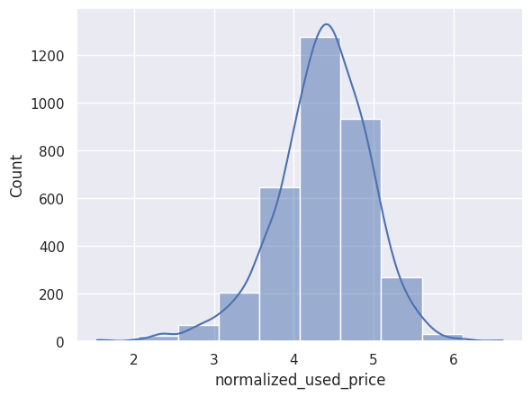

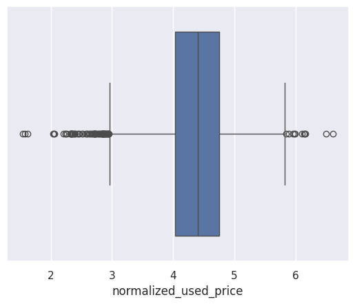

```python
# histogram and boxplot for normalized_used_price
sns.histplot(data['normalized_used_price'], bins=10, kde = True)
plt.show()
sns.boxplot(x=data['normalized_used_price'])
plt.show()
```

```python
median_normalized_used_price = data['normalized_used_price'].median()
print("Median Normalized Used Price:", median_normalized_used_price)
```

```
Median Normalized Used Price: 4.405132623
```

*Observations*

1. The median price is 4.40 Euros.
2. Some outliers can be observed. Some prices are out of the normal range, some way below the minimum and some way above the maximum.

*normalized_new_price*

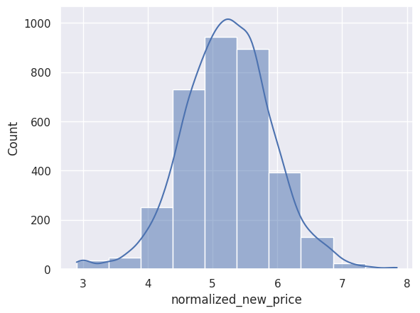

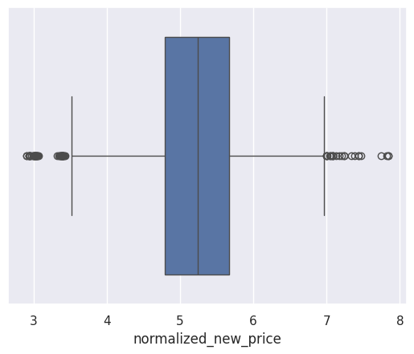

```python
# Histogram and boxplot for normalized_new_price
sns.histplot(data['normalized_new_price'], bins=10, kde = True)
plt.show()
sns.boxplot(x=data['normalized_new_price'])
plt.show()
```

```python
median_normalized_new_price = data['normalized_new_price'].median()
print("Median Normalized New Price:", median_normalized_new_price)
```

```
Median Normalized New Price: 5.2458918494999995
```

*Observations*

1. The median price is approximately 5.245 Euros.
2. The data appears to be normally distributed
3. Some outliers can be observed. Some prices are out of the normal range, some way below the minimum and some way above the maximum.

*screen_size*

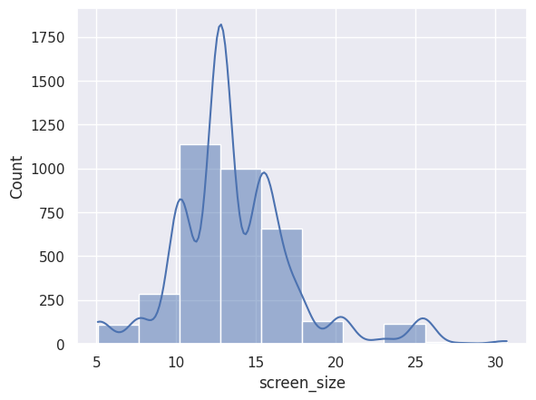

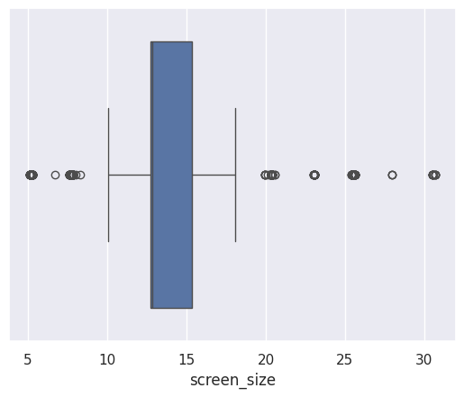

```python
# Histogram and boxplot for screen_size
sns.histplot(data['screen_size'], bins=10, kde = True)
plt.show()
sns.boxplot(x=data['screen_size'])
plt.show()
```

```python
median_screen_size = data['screen_size'].median()
print("Median Screen Size:", median_screen_size)
```

```
Median Screen Size: 12.83
```

*Observations*

1. From the histplot, the data is not normally distributed.
2. The boxplot has many outliers and is skewed to the right.
3. The median screen size is 12.83 cm

*main_camera_mp*

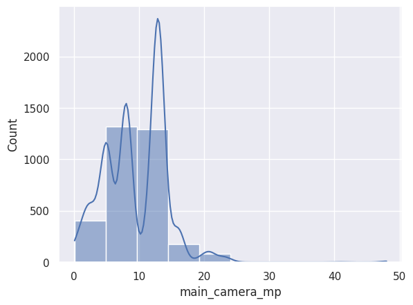

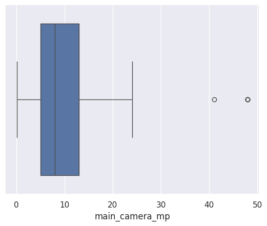

```python
# histogram and boxplot for main_camera_mp
sns.histplot(data['main_camera_mp'], bins=10, kde = True)
plt.show()
sns.boxplot(x=data['main_camera_mp'])
plt.show()
```

```python
median_main_camera_mp = data['main_camera_mp'].median()
print("Main Camera Mp:", median_main_camera_mp)
```

```
Main Camera Mp: 8.0
```

*Observations*

1. The data is skewed to the right. Most of the values are clustered around 5 and 15 megapixels. Most of the phones have cameras that fall within this range.
2. Median is 8.0 mp
3. The boxplot has two outliers beyond the upper whisker

*selfie_camera_mp*

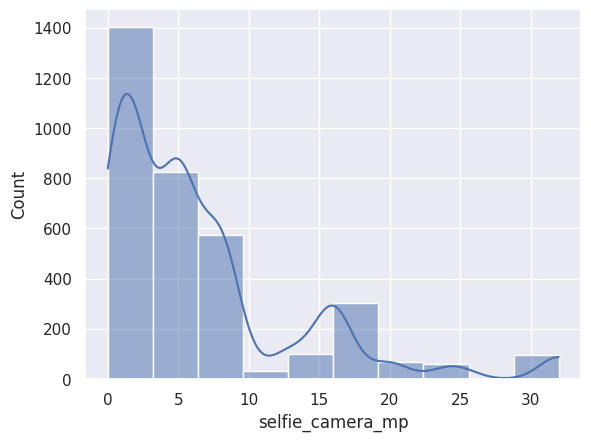

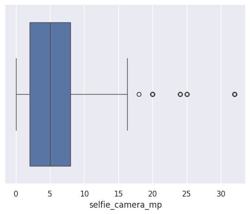

```python
# Histogram and boxplot for selfie_camera_mp
sns.histplot(data['selfie_camera_mp'], bins=10, kde = True)
plt.show()
sns.boxplot(x=data['selfie_camera_mp'])
plt.show()
```

```python
median_selfie_camera_mp = data['selfie_camera_mp'].median()
print("Selfie Camera Mp:", median_selfie_camera_mp)
```

```
Selfie Camera Mp: 5.0
```

*Observations*

1. The data is not normally distributed and is skewed to the right.
2. The median is 5.0 mp
3. The boxplot has five outliers indicating values outside the normal range.

*int_memory*

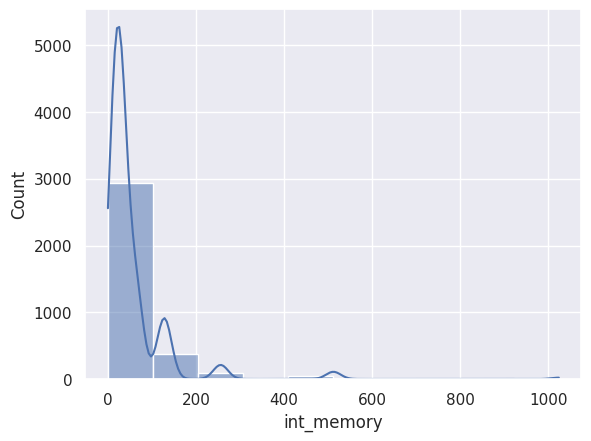

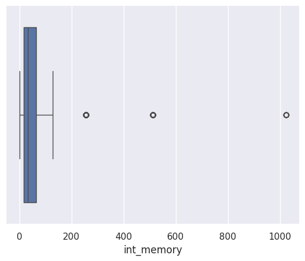

```python
# Histogram and boxplot for int_memory
sns.histplot(data['int_memory'], bins=10, kde = True)
plt.show()
sns.boxplot(x=data['int_memory'])
plt.show()
```

```python
median_int_memory = data['int_memory'].median()
print("Int Memory:", median_int_memory)
```

```
Int Memory: 32.0
```

*Observations*

1. Data is not normally distributed and is skewed to the right.
2. The boxplot has 3 outliers indicating extremely high internal memory values outside the regular memory.
3. The median internal memory is 32gb.

*weight*

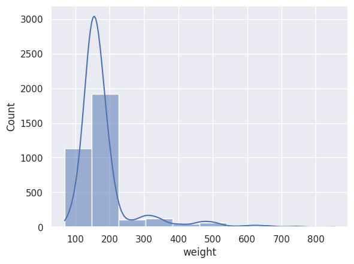

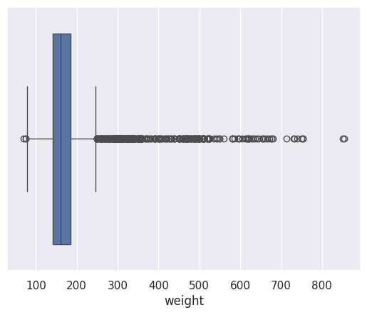

```python
 # Histogram and boxplot for weight
sns.histplot(data['weight'], bins=10, kde = True)
plt.show()
sns.boxplot(x=data['weight'])
plt.show()
```

```python
median_weight = data['weight'].median()
print("weight:", median_weight)
```

```
weight: 160.0
```

*Observations*

*battery*

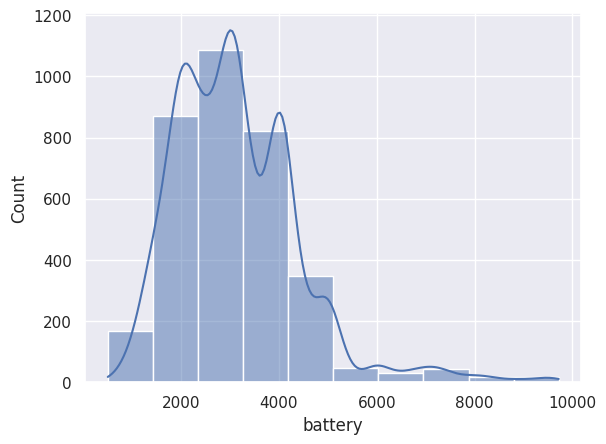

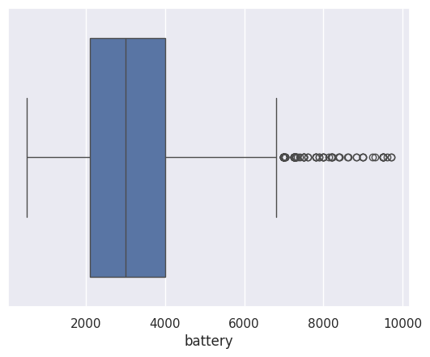

```python
 # Histogram and boxplot for battery
sns.histplot(data['battery'], bins=10, kde = True)
plt.show()
sns.boxplot(x=data['battery'])
plt.show()
```

```python
median_battery = data['battery'].median()
print("battery:", median_battery)
```

```
battery: 3000.0
```

*Observations*

1. The data is skewed to the right and is not normally distributed.
2. The median battery size is 3000mAh.
3. A greater number of the devices have a battery size ranging between 2000mAH and 4000mAh

*days_used*

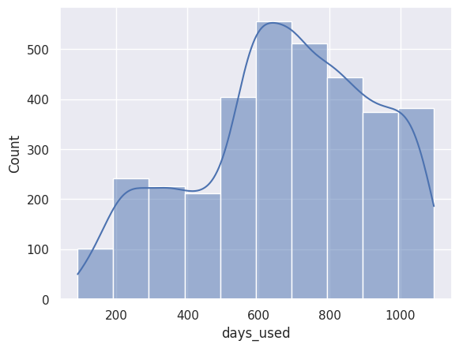

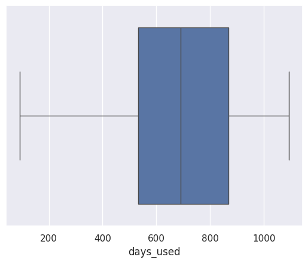

```python
# Histogram and boxplot for days_used
sns.histplot(data['days_used'], bins=10, kde = True)
plt.show()
sns.boxplot(x=data['days_used'])
plt.show()
```

```python
median_days_used = data['days_used'].median()
print("days_used:", median_days_used)
```

```
days_used: 690.5
```

*Observations*

```python
# Import functions to create labelled barplots
# function to create labeled barplots


def labeled_barplot(data, feature, perc=False, n=None):
    """
    Barplot with percentage at the top

    data: dataframe
    feature: dataframe column
    perc: whether to display percentages instead of count (default is False)
    n: displays the top n category levels (default is None, i.e., display all levels)
    """

    total = len(data[feature])  # length of the column
    count = data[feature].nunique()
    if n is None:
        plt.figure(figsize=(count + 2, 6))
    else:
        plt.figure(figsize=(n + 2, 6))

    plt.xticks(rotation=90, fontsize=15)
    ax = sns.countplot(
        data=data,
        x=feature,
        order=data[feature].value_counts().index[:n],
    )

    for p in ax.patches:
        if perc == True:
            label = "{:.1f}%".format(
                100 * p.get_height() / total
            )  # percentage of each class of the category
        else:
            label = p.get_height()  # count of each level of the category

        x = p.get_x() + p.get_width() / 2  # width of the plot
        y = p.get_height()  # height of the plot

        ax.annotate(
            label,
            (x, y),
            ha="center",
            va="center",
            size=12,
            xytext=(0, 5),
            textcoords="offset points",
        )  # annotate the percentage

    plt.show()  # show the plot
```

*brand_name*

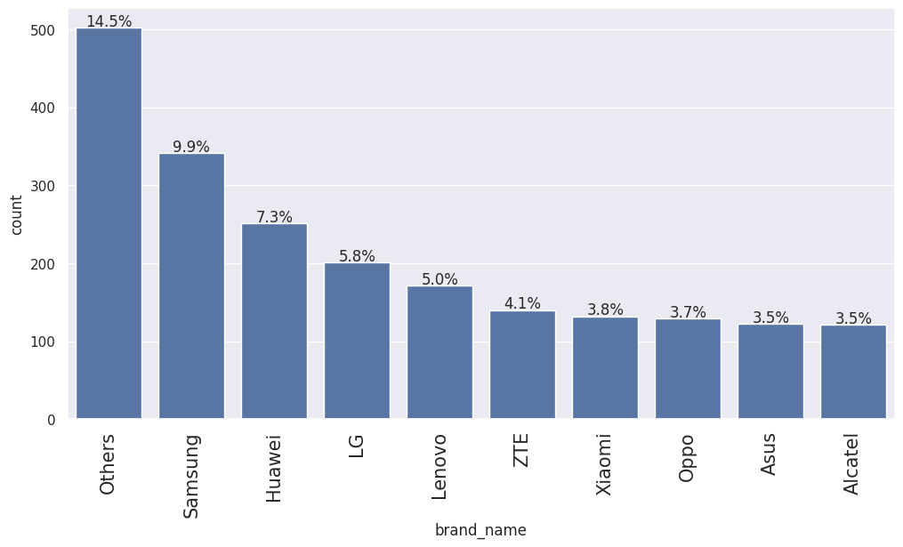

```python
labeled_barplot(data, "brand_name", perc=True, n=10)  ## Complete the code to create labeled_barplot for 'brand_name'
```

*Observations*

Question 2: What percentage of the used device market is dominated by Android devices?

*os*

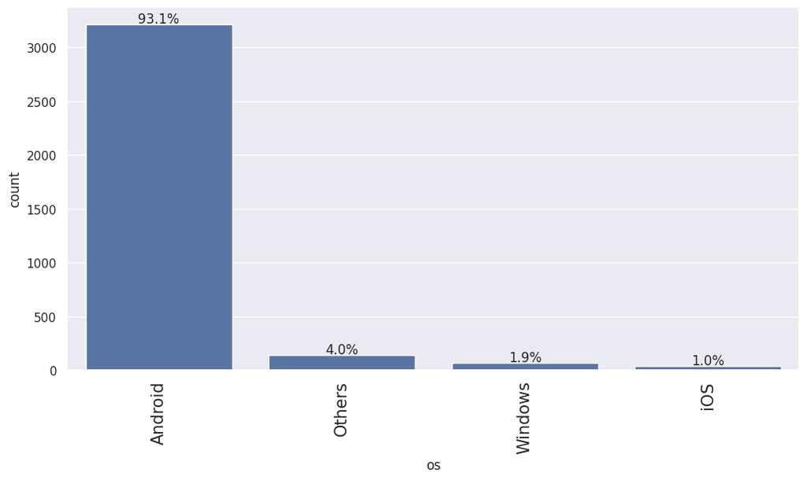

```python
labeled_barplot(data, "os", perc=True, n=10)  ## Complete the code to create labeled_barplot for 'os'
```

*Observations*

1. Android used devices dominate the market, and account for 93.1% of the market share.
2. iOS devices account for 1.0% of the market share.
3. Other operating systems account for 4.0% of the market share.
4. Windows account for 1.9% of the market share.

*4g*

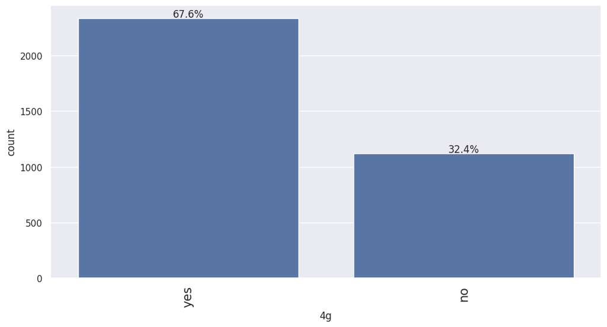

```python
labeled_barplot(data, "4g", perc=True, n=10)  ## Complete the code to create labeled_barplot for '4g'
```

*Observations*

1. A greater number of devices have 4g capability (about 67.6%). 32.45 do not have 4g capability.
2. Devices with 4g capability appears to be a common feature on the market.
3. It will great to see how devices with 5g capability play out on the market based on our observations with 4g-enabled devices.

*5g*

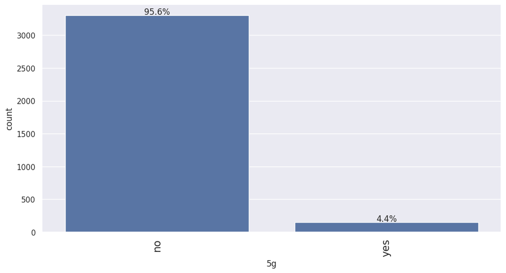

```python
labeled_barplot(data, "5g", perc=True, n=10)  ## Complete the code to create labeled_barplot for '5g'
```

*Observations*

1. A greater number of devices do not have 5g capability (about 95.6%). Only 4.4% have 5g capability.
2. Devices with 5g capability do not appear to be a common feature on the market. This is to be expected, as 5G technology is still relatively new and is being introduced gradually.
3. We should expect 5g-enabled devices to dominate the market in the coming years as the pace of technology advances.

*release_year*

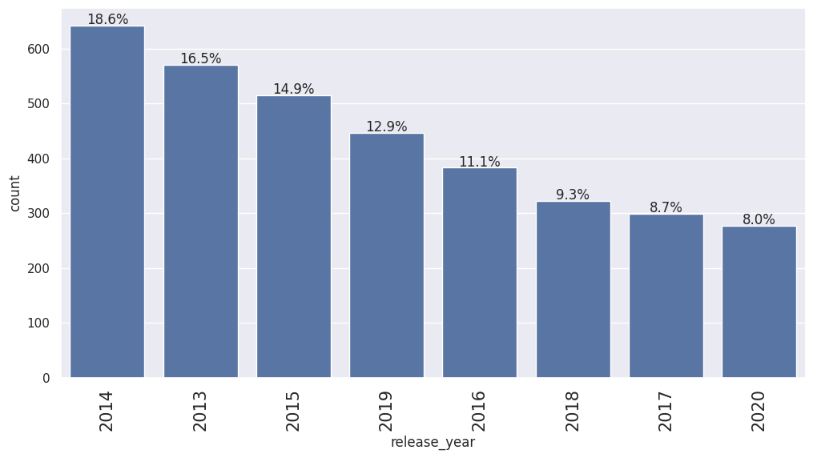

```python
labeled_barplot(data, "release_year", perc=True, n=10)  ## Complete the code to create labeled_barplot for 'release_year'
```

*Observations*

1. 18.6% of the devices had a release year of 2014. This is followed by 16.5% in 2013, 14.9% in 2015, 12.9% in 2019, and 11.1% in 2016.
2. The distribution is skewed to the right, indicating that more devices in the dataset were released between 2013 and 2015.